# MPDW 7

Rahmandani Bardianto G1401231029

2025-10-03

# 1 Import dan split

```r
library(ggplot2)
library(tsibble)
library(tseries)
library(MASS)
library(lubridate)
library(dplyr)
data_btc1 = read.csv("C:/Users/PC/Downloads/Harga btc_kelompok 10.csv")

data_btc= data_btc1[829:1656,]
head(data_btc)
```

```
##          date price
## 829  4/8/2013 187.5
## 830  4/9/2013 230.0
## 831 4/10/2013 165.0
## 832 4/11/2013 124.9
## 833 4/12/2013 117.0
## 834 4/13/2013  93.0
```

```r
n_total <- nrow(data_btc)
n_train <- floor(0.8 * n_total)

data_btc_train <- data_btc[1:n_train, ]
data_btc_test  <- data_btc[(n_train + 1):n_total, ]

data_btc_train <- data_btc_train %>% mutate(indeks_split = row_number())
data_btc_test  <- data_btc_test  %>% mutate(indeks_split = row_number())
```

# 2 Plot time series

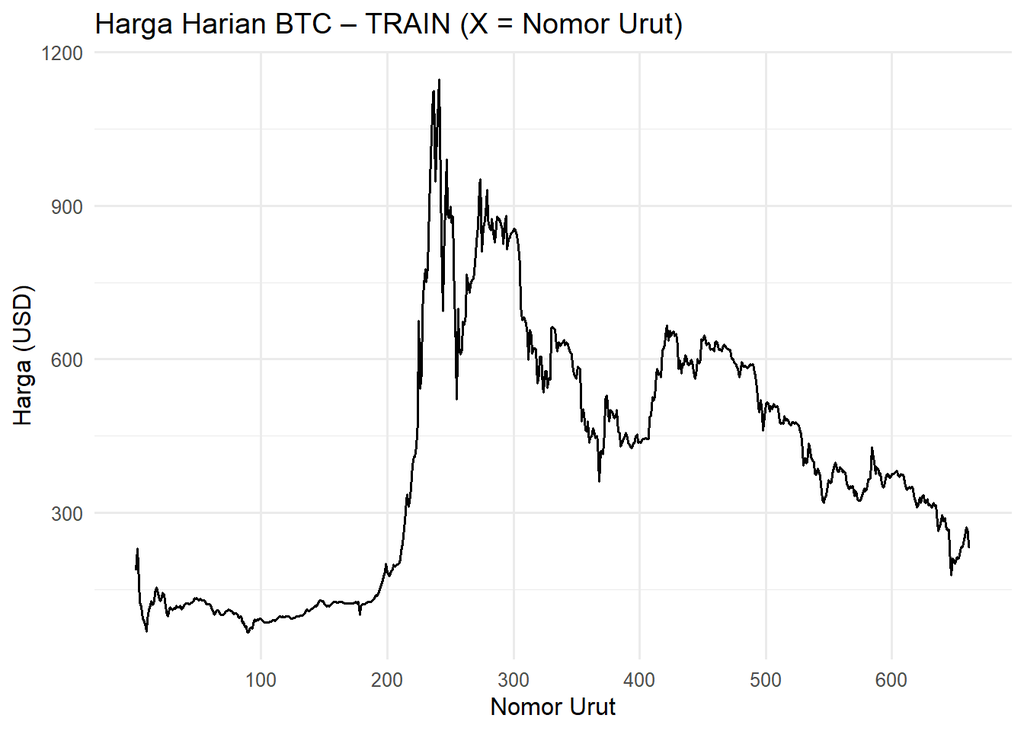

```r
btc_train <- data_btc_train |>
  transmute(
    tanggal = mdy(date),
    tanggal = coalesce(tanggal, as.Date(date)),
    harga   = as.numeric(price)
  ) |>
  filter(!is.na(tanggal), !is.na(harga)) |>
  arrange(tanggal) |>
  distinct(tanggal, .keep_all = TRUE) |>
  mutate(indeks = row_number())

ggplot(btc_train, aes(x = indeks, y = harga)) +
  geom_line(linewidth = 0.6) +
  scale_x_continuous(
    breaks = seq(100, nrow(btc_train), by = 100),
    minor_breaks = NULL,
    limits = c(1, nrow(btc_train))
  ) +
  labs(
    x = "Nomor Urut",
    y = "Harga (USD)",
    title = "Harga Harian BTC – TRAIN (X = Nomor Urut)"
  ) +
  theme_minimal(base_size = 12)
```

## Hasil Plot time series Tidak stasioner dalam ragam karena memiliki lebar pita yang cenderung tidak sama

# 3 Plot ACF

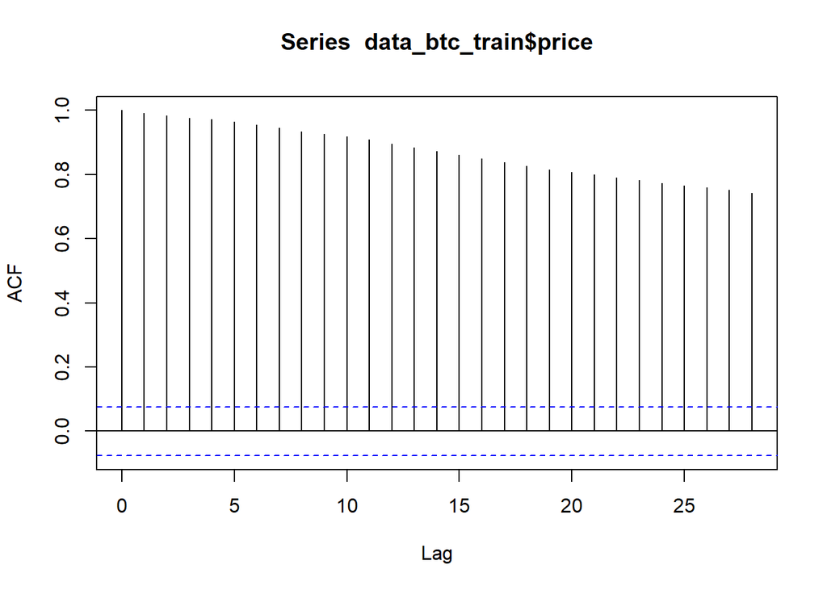

```r
acf(data_btc_train$price)
```

## Hasil ACF Berdasarkan plot ACF, terlihat bahwa plot ACF pada data tersebut menurun secara perlahan (tails off slowly) yang menandakan data tidak stasioner dalam rataan # Uji ADF

```r
tseries::adf.test(data_btc_train$price)
```

```
##
##  Augmented Dickey-Fuller Test
##
## data:  data_btc_train$price
## Dickey-Fuller = -1.5437, Lag order = 8, p-value = 0.7715
## alternative hypothesis: stationary
```

## 3.1 Hasil ADF

Karena p-value > 0.05 maka tak tolak H0 dan menandakan bahwa data tidak stasioner dalam rataan

# 4 box-cox

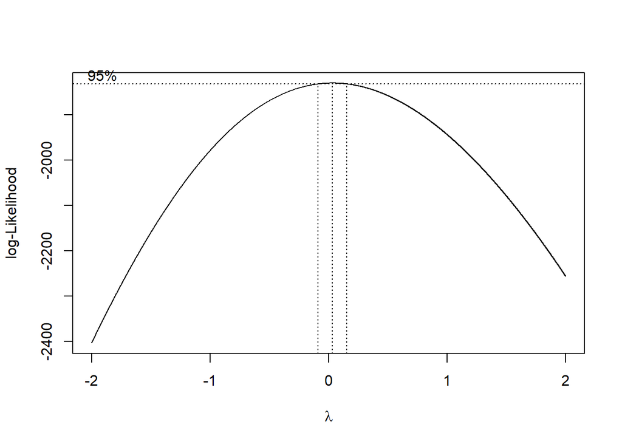

```r
btc_train <- data_btc_train |>
  transmute(
    tanggal = mdy(date),
    tanggal = coalesce(tanggal, as.Date(date)),
    harga   = as.numeric(price)
  ) |>
  filter(!is.na(tanggal), !is.na(harga)) |>
  arrange(tanggal) |>
  distinct(tanggal, .keep_all = TRUE) |>
  mutate(indeks = row_number())


bc <- boxcox(
  harga ~ indeks,
  data   = btc_train,
  lambda = seq(-2, 2, by = 0.0001)
)
```

```r
lambda <- bc$x[which.max(bc$y)]
ci_lambda <- bc$x[bc$y > max(bc$y) - 0.5 * qchisq(0.95, 1)]
ci_lower  <- min(ci_lambda)
ci_upper  <- max(ci_lambda)

c(Lambda = round(lambda, 6),
  Batas_Bawah = round(ci_lower, 6),
  Batas_Atas  = round(ci_upper, 6))
```

```
##      Lambda Batas_Bawah  Batas_Atas
##      0.0317     -0.0884      0.1529
```

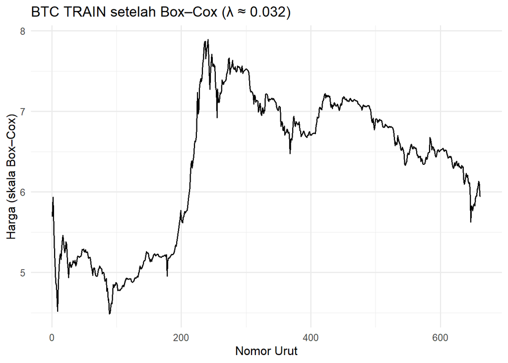

```r
boxcoxF <- function(x, lam) if (abs(lam) < 1e-8) log(x) else (x^lam - 1) / lam

boxcox_awal <- btc_train |>
  mutate(
    hargaBox     = boxcoxF(harga, lambda),
    diff1        = dplyr::lag(hargaBox, default = NA),
    hargaBoxDiff = c(NA, diff(hargaBox, lag = 1))
  )


ggplot(boxcox_awal, aes(x = indeks, y = hargaBox)) +
  geom_line(linewidth = 0.6) +
  labs(title = paste0("BTC TRAIN setelah Box–Cox (λ ≈ ", round(lambda, 3), ")"),
       x = "Nomor Urut", y = "Harga (skala Box–Cox)") +
  theme_minimal(base_size = 12)
```

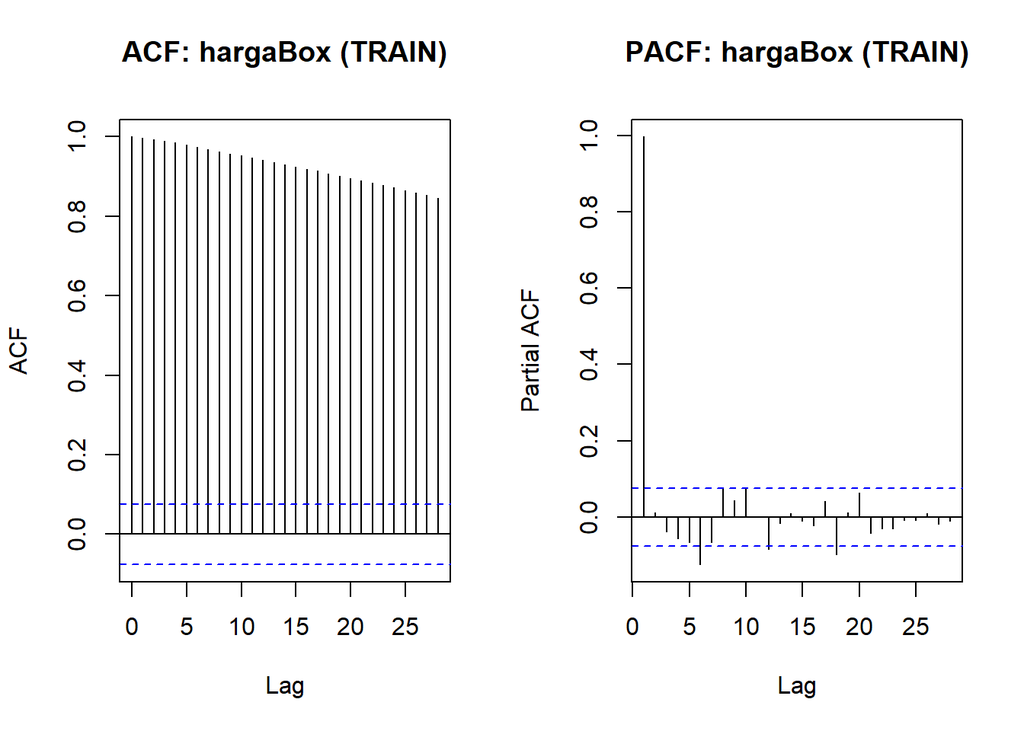

```r
par(mfrow = c(1,2))
acf(boxcox_awal$hargaBox, na.action = na.omit, main = "ACF: hargaBox (TRAIN)")
pacf(boxcox_awal$hargaBox, na.action = na.omit, main = "PACF: hargaBox (TRAIN)")
```

```r
par(mfrow = c(1,1))


tseries::adf.test(na.omit(boxcox_awal$hargaBox), alternative = "stationary")
```

```
##
##  Augmented Dickey-Fuller Test
##
## data:  na.omit(boxcox_awal$hargaBox)
## Dickey-Fuller = -0.70689, Lag order = 8, p-value = 0.9699
## alternative hypothesis: stationary
```

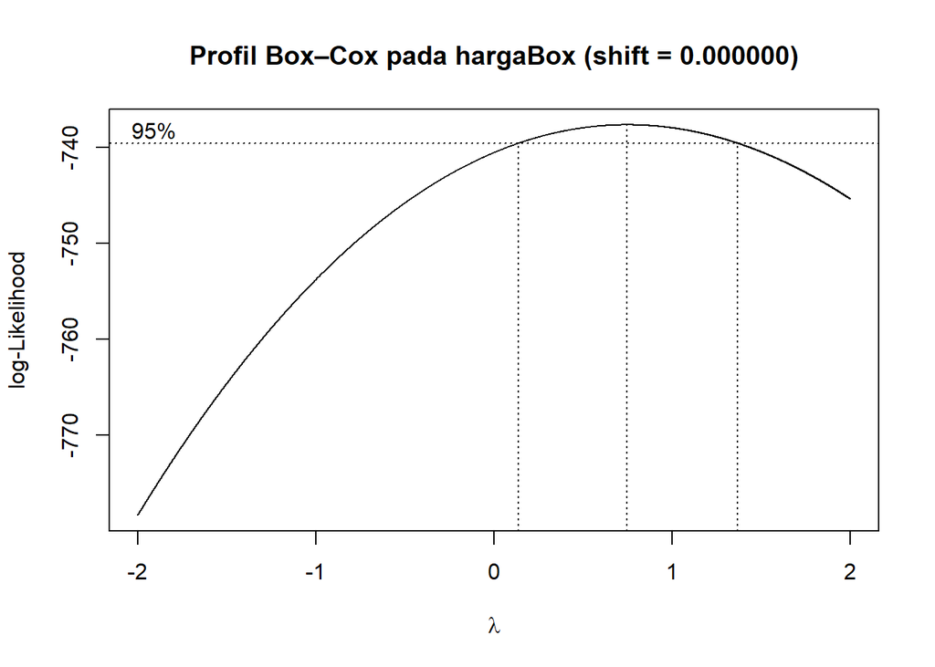

```r
# Seri hasil transform (level)
z <- na.omit(boxcox_awal$hargaBox)

# Geser tipis supaya > 0 (Box-Cox mensyaratkan y > 0)
m     <- min(z)
shift <- if (m <= 0) -m + 1e-6 else 0
z_pos <- z + shift
idx   <- seq_along(z_pos)

# Plot profil Box–Cox (hanya plot)
bc2 <- boxcox(
  z_pos ~ idx,
  lambda = seq(-2, 2, by = 0.0005),  # grid halus
  plotit = TRUE                      # tampilkan plot
)
title(main = sprintf("Profil Box–Cox pada hargaBox (shift = %.6f)", shift))
```

##Hasil Setelah transformasi Boxcox Setelah melakukan transformasi boxcox data masih menunjukan bahwa data tidak stasioner dalam rataan yang bisa diketahui dengan melihat adf test, plot time series dan acf

# 5 Differensing hasil transformasi boxcox

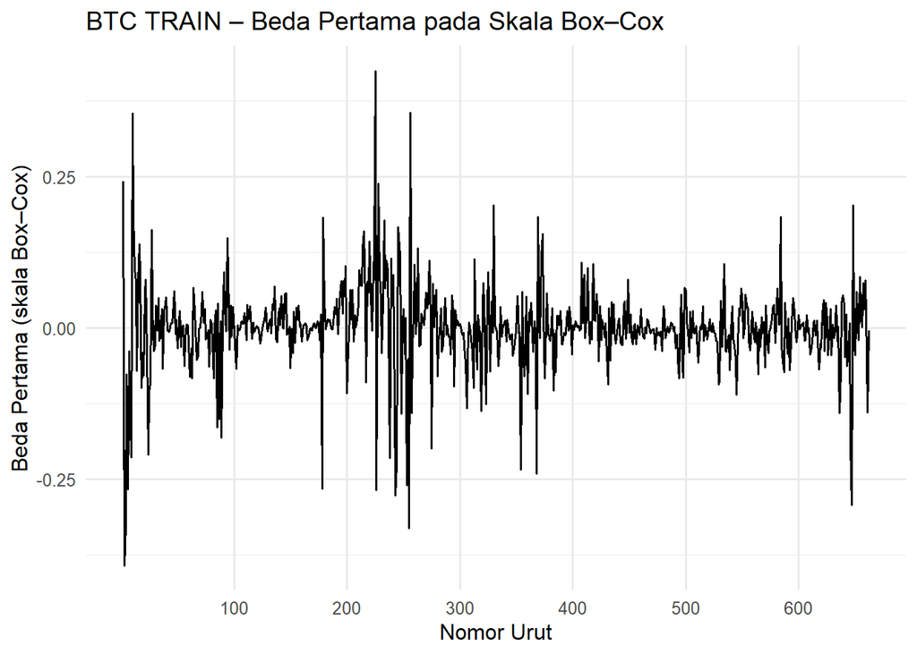

```r
seriDiff <- diff(boxcox_awal$hargaBox, differences = 1)

btcBoxDiff <- data.frame(
  indeks       = boxcox_awal$indeks[-1],
  hargaBoxDiff = seriDiff
)


library(ggplot2)
ggplot(btcBoxDiff, aes(indeks, hargaBoxDiff)) +
  geom_line(linewidth = 0.6) +
  scale_x_continuous(
    breaks = seq(100, max(btcBoxDiff$indeks), by = 100),
    minor_breaks = NULL
  ) +
  labs(
    title = "BTC TRAIN – Beda Pertama pada Skala Box–Cox",
    x = "Nomor Urut", y = "Beda Pertama (skala Box–Cox)"
  ) +
  theme_minimal(base_size = 12)
```

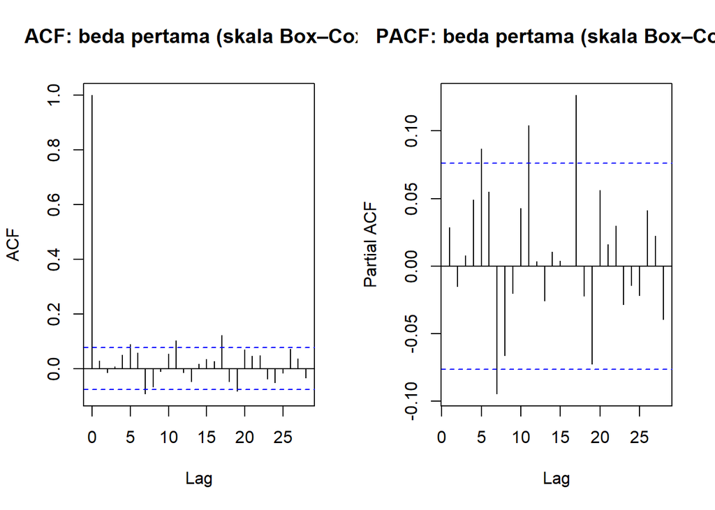

```r
par(mfrow = c(1,2))
acf(btcBoxDiff$hargaBoxDiff, main = "ACF: beda pertama (skala Box–Cox)")
pacf(btcBoxDiff$hargaBoxDiff, main = "PACF: beda pertama (skala Box–Cox)")
```

```r
par(mfrow = c(1,1))


library(tseries)
adf_diff <- tseries::adf.test(na.omit(btcBoxDiff$hargaBoxDiff), alternative = "stationary")
print(adf_diff)
```

```
##
##  Augmented Dickey-Fuller Test
##
## data:  na.omit(btcBoxDiff$hargaBoxDiff)
## Dickey-Fuller = -8.9566, Lag order = 8, p-value = 0.01
## alternative hypothesis: stationary
```

```r
if (adf_diff$p.value <= 0.05) {
  cat("KESIMPULAN: Beda pertama pada skala Box–Cox sudah stasioner (p ≤ 0.05).\n")
} else {
  cat("KESIMPULAN: Belum stasioner; pertimbangkan differencing tambahan / komponen musiman.\n")
}
```

```
## KESIMPULAN: Beda pertama pada skala Box–Cox sudah stasioner (p ≤ 0.05).
```

### 5.0.1 Hasil Boxcox +differensing

Uji adf, plot acf, dan lambda menunjukan bahwa data termasuk stasioner setelah diterapkan transformasi boxcox+diferensing ordo 1

```r
library(ggplot2)
library(tsibble)
library(tseries)
library(MASS)
library(forecast)
library(TSA)
library(TTR)
library(aTSA)
library(graphics)
```

```r
fix_train <- btcBoxDiff
fix_train$indeks <- seq_len(nrow(fix_train))
fix_train$indeks <- seq_len(nrow(fix_train))
names(fix_train)[names(fix_train) == "hargaBoxDiff"] <- "harga"

head(fix_train)
```

```
##   indeks       harga
## 1      1  0.24195275
## 2      2 -0.39255059
## 3      3 -0.32591045
## 4      4 -0.07606538
## 5      5 -0.26601474
## 6      6 -0.03783679
```

# 6 Eksplorasi

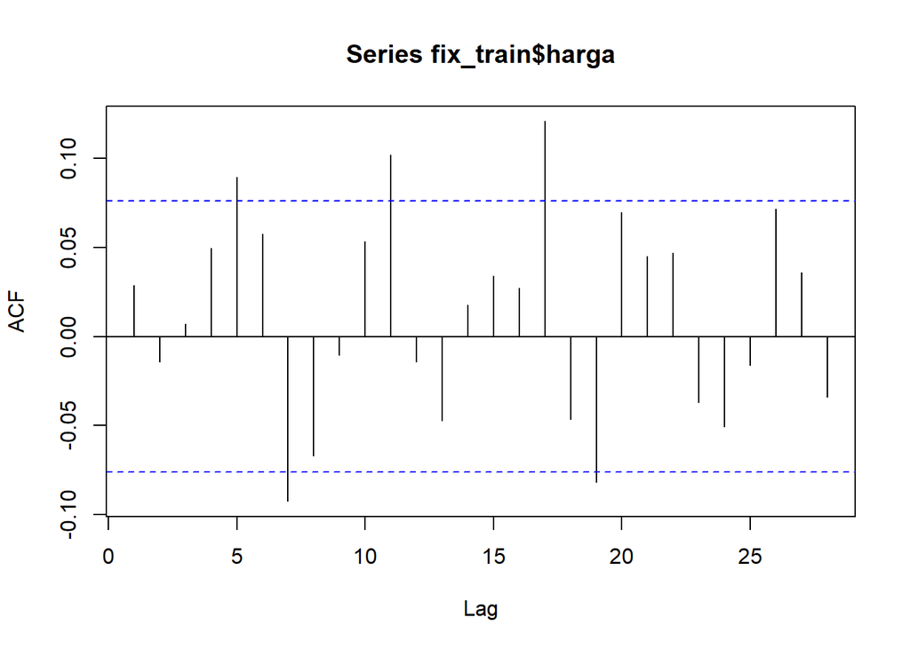

```r
acf(fix_train$harga)
```

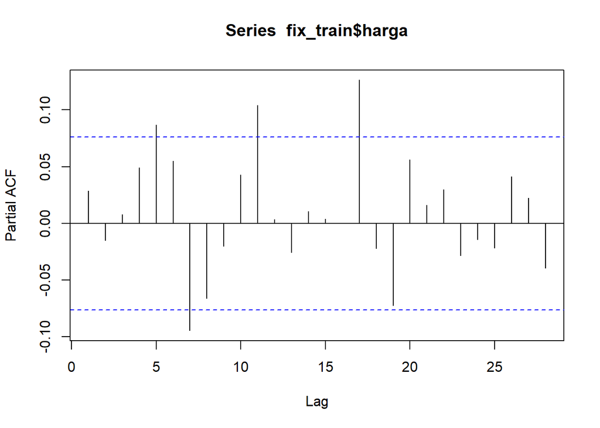

```r
pacf(fix_train$harga)
```

```r
eacf(fix_train$harga)
```

```
## AR/MA
##   0 1 2 3 4 5 6 7 8 9 10 11 12 13
## 0 o o o o x o x o o o x  o  o  o
## 1 x o o o o o x x o o x  o  o  o
## 2 x o o o o o o o o o o  o  o  o
## 3 x x x o o o o o o o o  o  o  o
## 4 x x x x o o o o o o o  o  o  o
## 5 x x x x x o o o o o o  o  o  o
## 6 x x x x x o o o o o o  o  o  o
## 7 x x o x x o o o o o o  o  o  o
```

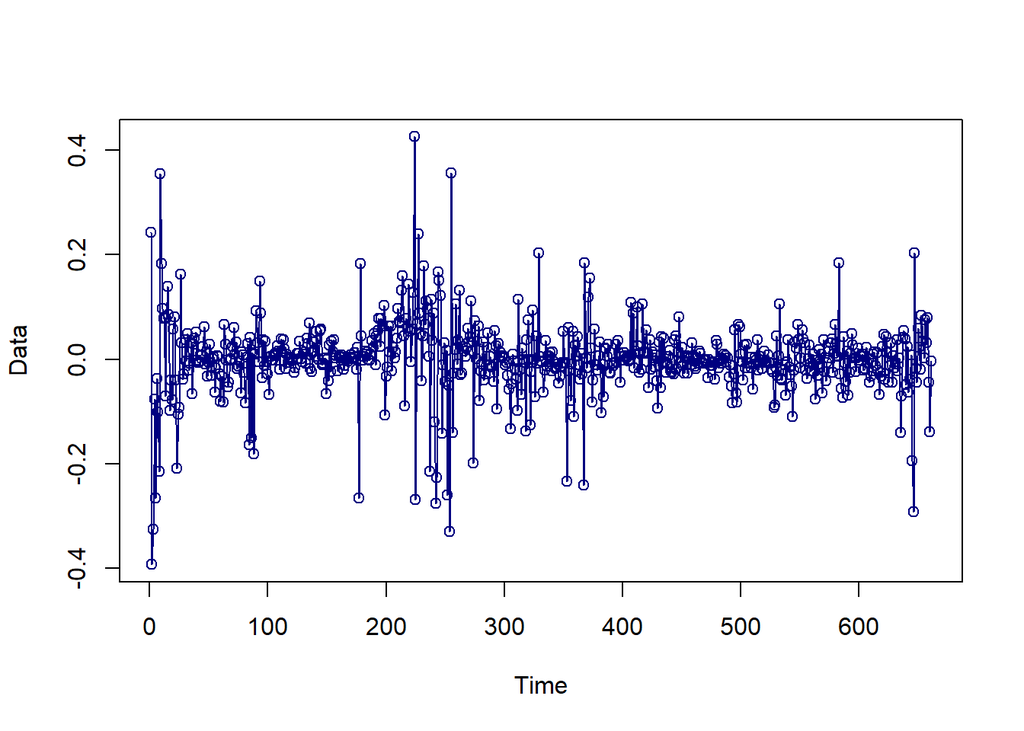

```r
plot(fix_train$harga,
     col = "navyblue",
     lwd = 1,
     type = "o",
     xlab = "Time",
     ylab = "Data")
```

##Hasil Berdasarkan eksplorasi didapatkan calon model arima dengan lag model_a = (1,1,1) model_b = (0,1,1) model_c = (0,1,2) model_d = (1,1,2) model_e = (2,1,1) model_f = (2,1,2)

Diferensing sudah dilakukan pada data jadi di 0 kan # Pendugaan Parameter ## Model a

```r
#model_a
model_a = Arima(fix_train$harga, order =c(1,0,1), method = "ML")
summary(model_a)
```

```
## Series: fix_train$harga
## ARIMA(1,0,1) with non-zero mean
##
## Coefficients:
##           ar1     ma1    mean
##       -0.2310  0.2625  0.0004
## s.e.   0.8583  0.8554  0.0029
##
## sigma^2 = 0.005245:  log likelihood = 798.9
## AIC=-1589.79   AICc=-1589.73   BIC=-1571.82
##
## Training set error measures:
##                         ME       RMSE        MAE      MPE     MAPE      MASE
## Training set -1.716109e-05 0.07225471 0.04332206 97.96421 104.0573 0.7212321
##                      ACF1
## Training set -0.002400049
```

```r
lmtest::coeftest(model_a)
```

```
##
## z test of coefficients:
##
##              Estimate  Std. Error z value Pr(>|z|)
## ar1       -0.23095044  0.85832764 -0.2691   0.7879
## ma1        0.26250072  0.85536527  0.3069   0.7589
## intercept  0.00040331  0.00288264  0.1399   0.8887
```

## 6.1 model b

```r
model_b = Arima(fix_train$harga, order = c(0,0,1), method ="ML")
summary(model_b)
```

```
## Series: fix_train$harga
## ARIMA(0,0,1) with non-zero mean
##
## Coefficients:
##          ma1    mean
##       0.0301  0.0004
## s.e.  0.0399  0.0029
##
## sigma^2 = 0.005237:  log likelihood = 798.85
## AIC=-1591.69   AICc=-1591.65   BIC=-1578.21
##
## Training set error measures:
##                         ME       RMSE        MAE      MPE     MAPE      MASE
## Training set -4.511244e-06 0.07226034 0.04333214 98.74016 103.7057 0.7213999
##                       ACF1
## Training set -0.0009640022
```

```r
lmtest::coeftest(model_b)
```

```
##
## z test of coefficients:
##
##             Estimate Std. Error z value Pr(>|z|)
## ma1       0.03010957 0.03987545  0.7551   0.4502
## intercept 0.00038921 0.00289540  0.1344   0.8931
```

## 6.2 Model c

```r
model_c = Arima(fix_train$harga, order = c(0,0,2), method ="ML")
summary(model_c)
```

```
## Series: fix_train$harga
## ARIMA(0,0,2) with non-zero mean
##
## Coefficients:
##          ma1      ma2    mean
##       0.0302  -0.0148  0.0004
## s.e.  0.0392   0.0383  0.0029
##
## sigma^2 = 0.005244:  log likelihood = 798.92
## AIC=-1589.84   AICc=-1589.78   BIC=-1571.87
##
## Training set error measures:
##                       ME      RMSE        MAE      MPE    MAPE      MASE
## Training set -3.7593e-06 0.0722521 0.04332247 97.68647 104.504 0.7212389
##                       ACF1
## Training set -0.0009483733
```

```r
lmtest::coeftest(model_c)
```

```
##
## z test of coefficients:
##
##              Estimate  Std. Error z value Pr(>|z|)
## ma1        0.03016851  0.03919956  0.7696   0.4415
## ma2       -0.01483652  0.03834681 -0.3869   0.6988
## intercept  0.00039163  0.00285371  0.1372   0.8908
```

## 6.3 Model d

```r
model_d = Arima(fix_train$harga, order = c(1,0,2), method ="ML")
summary(model_d)
```

```
## Series: fix_train$harga
## ARIMA(1,0,2) with non-zero mean
##
## Coefficients:
##          ar1     ma1      ma2    mean
##       0.0149  0.0153  -0.0152  0.0004
## s.e.  0.9708  0.9698   0.0434  0.0029
##
## sigma^2 = 0.005252:  log likelihood = 798.92
## AIC=-1587.84   AICc=-1587.75   BIC=-1565.37
##
## Training set error measures:
##                         ME       RMSE        MAE      MPE     MAPE      MASE
## Training set -5.158388e-06 0.07225221 0.04332287 97.71251 104.5497 0.7212455
##                       ACF1
## Training set -0.0009633578
```

```r
lmtest::coeftest(model_d)
```

```
##
## z test of coefficients:
##
##             Estimate Std. Error z value Pr(>|z|)
## ar1        0.0148922  0.9708128  0.0153   0.9878
## ma1        0.0153014  0.9697622  0.0158   0.9874
## ma2       -0.0152367  0.0434138 -0.3510   0.7256
## intercept  0.0003931  0.0028533  0.1378   0.8904
```

## 6.4 Model e

```r
model_e = Arima(fix_train$harga, order = c(2,0,1), method ="ML")
summary(model_e)
```

```
## Series: fix_train$harga
## ARIMA(2,0,1) with non-zero mean
##
## Coefficients:
##          ar1      ar2     ma1    mean
##       0.0149  -0.0166  0.0153  0.0004
## s.e.  0.9239   0.0460  0.9232  0.0028
##
## sigma^2 = 0.005252:  log likelihood = 798.93
## AIC=-1587.85   AICc=-1587.76   BIC=-1565.38
##
## Training set error measures:
##                         ME       RMSE        MAE      MPE     MAPE      MASE
## Training set -5.087956e-06 0.07225156 0.04332238 97.68481 104.7304 0.7212374
##                       ACF1
## Training set -0.0009480944
```

```r
lmtest::coeftest(model_e)
```

```
##
## z test of coefficients:
##
##              Estimate  Std. Error z value Pr(>|z|)
## ar1        0.01490586  0.92388755  0.0161   0.9871
## ar2       -0.01655112  0.04604944 -0.3594   0.7193
## ma1        0.01528106  0.92322768  0.0166   0.9868
## intercept  0.00039342  0.00284892  0.1381   0.8902
```

## 6.5 Model f

```r
model_f = Arima(fix_train$harga, order = c(2,0,2), method ="ML")
summary(model_f)
```

```
## Series: fix_train$harga
## ARIMA(2,0,2) with non-zero mean
##
## Coefficients:
##          ar1      ar2      ma1     ma2    mean
##       0.7384  -0.9752  -0.7333  0.9264  0.0004
## s.e.  0.0241   0.0180   0.0410  0.0261  0.0027
##
## sigma^2 = 0.005076:  log likelihood = 810.41
## AIC=-1608.82   AICc=-1608.69   BIC=-1581.86
##
## Training set error measures:
##                         ME       RMSE        MAE      MPE     MAPE      MASE
## Training set -4.022868e-05 0.07097307 0.04354033 54.40813 195.4067 0.7248659
##                    ACF1
## Training set 0.01162326
```

```r
lmtest::coeftest(model_f)
```

```
##
## z test of coefficients:
##
##             Estimate Std. Error z value Pr(>|z|)
## ar1        0.7384161  0.0240666  30.682   <2e-16 ***
## ar2       -0.9752069  0.0180070 -54.157   <2e-16 ***
## ma1       -0.7333290  0.0409951 -17.888   <2e-16 ***
## ma2        0.9264037  0.0261407  35.439   <2e-16 ***
## intercept  0.0004474  0.0026635   0.168   0.8666
## ---
## Signif. codes:  0 '***' 0.001 '**' 0.01 '*' 0.05 '.' 0.1 ' ' 1
```

###Hasil pendugaan parameter Berdasarkan pendugaan parameter di atas dengan nilai aic dan signifikansi lag, maka dipilih model ARIMA (2,1,2) / model_f

# 7 Analisis Sisaan

## 7.1 Eksplorasi sisaan

```r
sisaan = model_f$residuals
par(mfrow=c(2,2))
car::qqPlot(sisaan)
```

```
## [1] 224   2
```

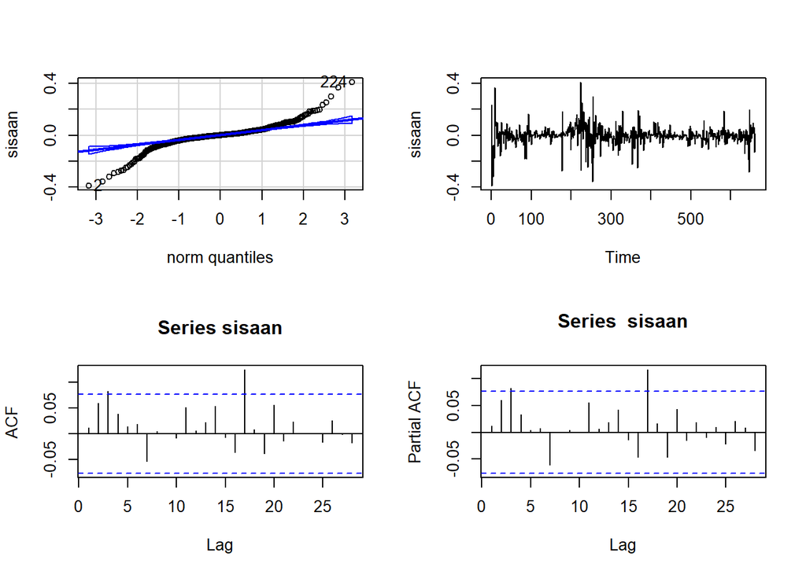

```r
plot(sisaan)
acf(sisaan)
pacf(sisaan)
```

```r
ks.test(sisaan,"pnorm")
```

```
##
##  Asymptotic one-sample Kolmogorov-Smirnov test
##
## data:  sisaan
## D = 0.4228, p-value < 2.2e-16
## alternative hypothesis: two-sided
```

```r
Box.test(sisaan, type = "Ljung")
```

```
##
##  Box-Ljung test
##
## data:  sisaan
## X-squared = 0.089707, df = 1, p-value = 0.7645
```

```r
Box.test((sisaan)^2, type = "Ljung")
```

```
##
##  Box-Ljung test
##
## data:  (sisaan)^2
## X-squared = 108.95, df = 1, p-value < 2.2e-16
```

```r
t.test(sisaan, mu = 0, conf.level = 0.95)
```

```
##
##  One Sample t-test
##
## data:  sisaan
## t = -0.014562, df = 660, p-value = 0.9884
## alternative hypothesis: true mean is not equal to 0
## 95 percent confidence interval:
##  -0.005464818  0.005384360
## sample estimates:
##     mean of x
## -4.022868e-05
```

# 8 Overfitting

```r
model3.da=Arima(fix_train$harga, order=c(3,0,3),method="ML")
summary(model3.da)
```

```
## Series: fix_train$harga
## ARIMA(3,0,3) with non-zero mean
##
## Coefficients:
##          ar1      ar2     ar3      ma1     ma2      ma3     mean
##       0.1063  -0.0618  0.9114  -0.0826  0.1041  -0.9414  -0.0013
## s.e.  0.0490   0.0498  0.0366   0.0386  0.0380   0.0325   0.0051
##
## sigma^2 = 0.005211:  log likelihood = 802.79
## AIC=-1589.58   AICc=-1589.36   BIC=-1553.63
##
## Training set error measures:
##                        ME       RMSE       MAE      MPE   MAPE      MASE
## Training set 0.0008956356 0.07180459 0.0434096 107.2555 149.52 0.7226893
##                     ACF1
## Training set 0.006100412
```

```r
lmtest::coeftest(model3.da)
```

```
##
## z test of coefficients:
##
##             Estimate Std. Error  z value  Pr(>|z|)
## ar1        0.1063473  0.0489532   2.1724  0.029824 *
## ar2       -0.0617577  0.0497981  -1.2402  0.214916
## ar3        0.9114304  0.0366373  24.8771 < 2.2e-16 ***
## ma1       -0.0826325  0.0386105  -2.1402  0.032342 *
## ma2        0.1041061  0.0380386   2.7369  0.006203 **
## ma3       -0.9413847  0.0325090 -28.9577 < 2.2e-16 ***
## intercept -0.0013333  0.0051365  -0.2596  0.795194
## ---
## Signif. codes:  0 '***' 0.001 '**' 0.01 '*' 0.05 '.' 0.1 ' ' 1
```

```r
sisa = model3.da$residuals
ks.test(sisa,"pnorm")
```

```
##
##  Asymptotic one-sample Kolmogorov-Smirnov test
##
## data:  sisa
## D = 0.41978, p-value < 2.2e-16
## alternative hypothesis: two-sided
```

```r
Box.test(sisa, type = "Ljung")
```

```
##
##  Box-Ljung test
##
## data:  sisa
## X-squared = 0.024711, df = 1, p-value = 0.8751
```

```r
Box.test((sisa)^2, type = "Ljung")
```

```
##
##  Box-Ljung test
##
## data:  (sisa)^2
## X-squared = 136.05, df = 1, p-value < 2.2e-16
```

```r
t.test(sisa, mu = 0, conf.level = 0.95)
```

```
##
##  One Sample t-test
##
## data:  sisa
## t = 0.32047, df = 660, p-value = 0.7487
## alternative hypothesis: true mean is not equal to 0
## 95 percent confidence interval:
##  -0.004592081  0.006383352
## sample estimates:
##    mean of x
## 0.0008956356
```

# 9 Forecasting

```r
library(forecast)
library(dplyr)
library(ggplot2)

# --- HORIZON ---
h <- nrow(data_btc_test)

# --- FORECAST di Δ(Box–Cox) ---
ramalan_f <- forecast::forecast(model_f, h = h)
print(ramalan_f)
```

```
##     Point Forecast       Lo 80      Hi 80      Lo 95     Hi 95
## 662   0.0027675915 -0.08853404 0.09406922 -0.1368662 0.1424014
## 663   0.0177272469 -0.07357556 0.10903005 -0.1219083 0.1573628
## 664   0.0109444522 -0.08045094 0.10233985 -0.1288327 0.1507216
## 665  -0.0086528320 -0.10011484 0.08280917 -0.1485319 0.1312262
## 666  -0.0165091538 -0.10798240 0.07496409 -0.1564054 0.1233871
## 667  -0.0031989811 -0.09478099 0.08838303 -0.1432616 0.1368636
## 668   0.0142910039 -0.07731065 0.10589265 -0.1258016 0.1543836
## 669   0.0142257178 -0.07742346 0.10587489 -0.1259396 0.1543910
## 670  -0.0028788447 -0.09461652 0.08885883 -0.1431795 0.1374218
## 671  -0.0154454615 -0.10718319 0.07629227 -0.1557462 0.1248553
## 672  -0.0080443659 -0.09986315 0.08377442 -0.1484691 0.1323803
## 673   0.0096757737 -0.08219016 0.10154171 -0.1308210 0.1501726
## 674   0.0155430104 -0.07633666 0.10742268 -0.1249748 0.1560608
## 675   0.0025946697 -0.08937390 0.09456324 -0.1380591 0.1432485
```

[output cut: 152 more lines]

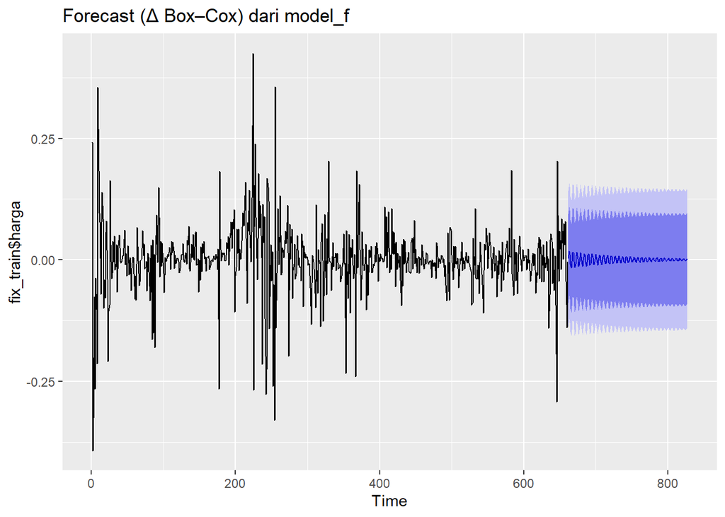

```r
autoplot(ramalan_f) + ggtitle("Forecast (Δ Box–Cox) dari model_f")
```

```r
data.ramalan.f  <- ramalan_f$mean
hasil.forc.Diff <- as.numeric(data.ramalan.f)

# --- TITIK AWAL LEVEL (Box–Cox) dari TRAIN ---
stopifnot(exists("boxcox_awal"), "hargaBox" %in% names(boxcox_awal))
pt_last <- tail(boxcox_awal$hargaBox, 1)   # << penting: didefinisikan di sini

# --- INVERSE DIFFERENCING -> LEVEL Box–Cox ---
hasil_box_level <- diffinv(hasil.forc.Diff, differences = 1) + pt_last
fc_box_level    <- hasil_box_level[-1]
stopifnot(length(fc_box_level) == h)

# --- INVERSE BOX–COX -> HARGA ASLI ---
stopifnot(exists("lambda"))
invBoxcox <- function(y, lam) if (abs(lam) < 1e-8) exp(y) else (lam*y + 1)^(1/lam)
pred_price <- invBoxcox(fc_box_level, lambda)

# --- AKTUAL TEST & PERBANDINGAN ---
aktual_price <- as.numeric(data_btc_test$price)
perbandingan.f <- data.frame(
  indeks         = data_btc_test$indeks_split,
  Aktual         = aktual_price,
  Hasil_Forecast = pred_price
)

print(head(perbandingan.f, 10))
```

```
##    indeks   Aktual Hasil_Forecast
## 1       1 226.5033       232.9466
## 2       2 216.9137       236.4460
## 3       3 226.3959       238.6318
## 4       4 237.5409       236.9021
## 5       5 226.9566       233.6354
## 6       6 226.7291       233.0075
## 7       7 216.7714       235.8253
## 8       8 222.4823       238.6631
## 9       9 227.3275       238.0861
## 10     10 222.8677       235.0138
```

```r
accuracy(ts(pred_price), ts(aktual_price))
```

```
##                ME     RMSE      MAE       MPE     MAPE      ACF1 Theil's U
## Test set 2.221477 19.75378 15.02317 0.3328146 5.939114 0.9275313  2.764129
```

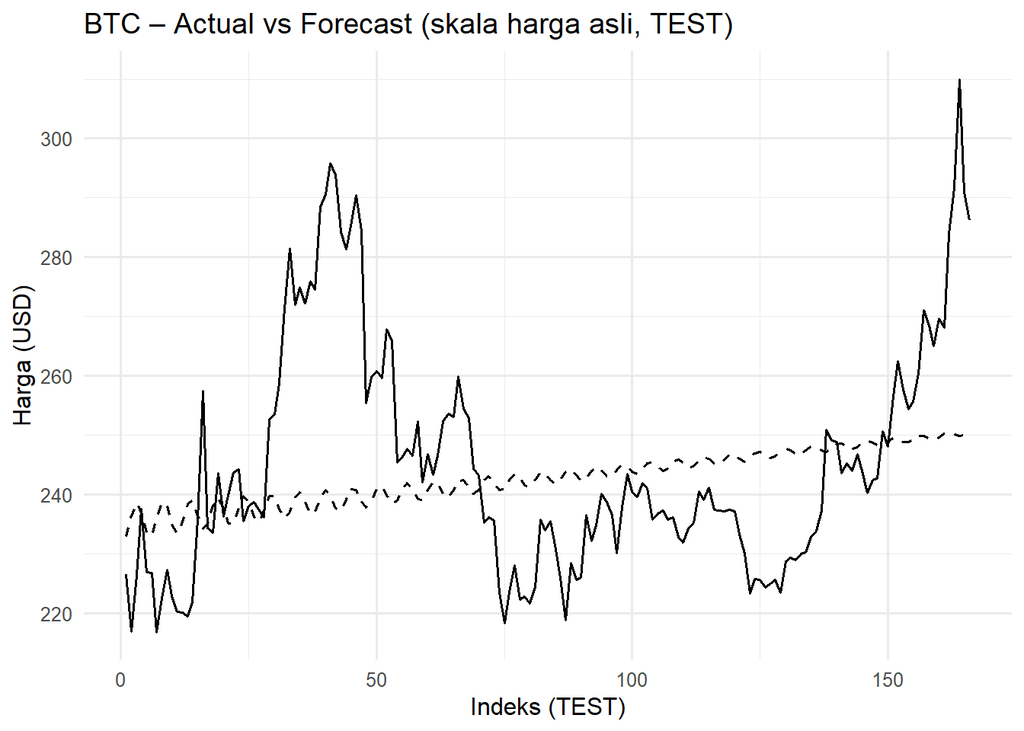

```r
# --- PLOT OVERLAY DI SKALA ASLI ---
ggplot(perbandingan.f, aes(indeks)) +
  geom_line(aes(y = Aktual), size = 0.6) +
  geom_line(aes(y = Hasil_Forecast), linetype = "dashed", size = 0.6) +
  labs(title = "BTC – Actual vs Forecast (skala harga asli, TEST)",
       x = "Indeks (TEST)", y = "Harga (USD)") +
  theme_minimal(base_size = 12)
```

# 10 Kesimpulan & sedikit rekomendasi selanjutnya

Transformasi Box–Cox + differencing berhasil membuat seri stasioner. ARIMA(2,1,2) memenuhi rata-rata residu = 0 tetapi melanggar normalitas dan homoskedastisitas. Ramalan dibuat di Δ(Box–Cox), lalu inverse differencing dan inverse Box–Cox ke harga asli.meski kesalahan persentase moderat, ACF1 tinggi dan Theil’s U > 1 menunjukkan performa lebih lemah daripada model naif (random walk).

Rekomendasi Tangani volatilitas: pasang GARCH(1,1) (atau EGARCH/GJR) di atas mean ARIMA dengan Student-t innovations. Periksa musiman mingguan (s=7): jika ada spike residu pada lag 7, uji SARIMA